# Statistiline andmeteadus ja visualiseerimine

Anna Laaneväli, Annegrete Palu

28 aprill 2017

Aastal 2015 korraldati IT-sekoris hange ostmaks sisse arendusresurssi. Hankele oodati tunnihinnapakkumisi järgmistele ametitele: nooremarendaja, vanemarendaja, front-end arendaja, arhitekt, analüütik, testija ja UX-disainer. Hankest võttis osa 22 Eestis tegutsevat IT-firmat, kusjuures üks pakkumine tehti kahe ettevõtte ühispakkumisena. Ehk siis üksteisega võistlevaid pakkumisi oli kokku 21. Ennatavalt mainime siinkohal ära, et tulenevalt raamlepingust, võitsid peaaegu kõik ettevõtted. Aga nüüd kõigest järgemööda.

Iga hankes osaleja pakkus tunnihinnad ametite lõikes, millega nad oleks nõus töö ära tegema. Seejuures võitis pakkumise teha kõikidele ametitele kui ka vaid ühele ametile. Nii saime teada, mis hindu küsisid tarkvara ettevõtted 2015. aastal. Kuna hanke korras pakutud tunnihinnad ei ole avalik info, vahetasime kõikide ettevõtete nimed ära väljamõeldud nimedega. Võimalik kokkulangevus pärisnimedega on juhuslik.

Tartus õpib 3. aasta infotehnoloogia tudeng Mati, kes ei ole veel otsustanud, millise ameti esindajaks ta pürgib. Mati on enda jaoks läbi mõelnud, et kindlasti mõjutab tema ametivalikut tulevikus saadav palk. Küll aga pole praegu Matil õrna aimugi, kui palju erinevate ametite esindajad teenivad. Vaatleme, kuidas jagunesid tunnihinnad ametite lõikes:

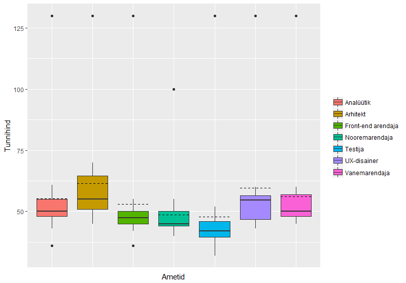

Joonis 1: hankes pakutud tunnihinnad eurodes ametite lõikes

Aritmeetiliste keskmiste järgi, mis on joonisel tähistatud katkendliku joonega, näeme, et kõige kõrgem tunnihind on arhitektidel, kellele vahetult järgnevad UX-disainerid. Kõige väiksemat tunnihinda küsitakse testijate pealt, neist pisut rohkem nooremarendajate eest. Kõik IT-tudengid, lisaks Matile, kes saavad innustust pürgida arhitektiks või UX-disaineriks, peaks siiski silmas pidama, et hanke korras pakutud tunnihinda ei maksta nende ametite esindajatele kohe peo peale. Tegu on summaga, millega müüakse nende ressurssi välja- oma osa haukavad sellest tugiteenuste töötajad nagu raamatupidajad, projektijuhid ja teised, kelleta ükski IT-ettevõte hakkama ei saaks. Nii nagu kõikide ametite puhul, siis ka arhitektide ja UX-disainerite töötasu sõltub nende teadmistest ja pädevusest. Küllap on oma roll saadavas tasus ka läbirääkimisoskustel. Seega ei tasu kõiki teisi ameteid hoobilt maha kanda.

Hea palk on Matile tähtis, mistõttu hakkas teda huvitama, millises ettevõttes on potensiaalselt kõige kõrgemad palgad ametite lõikes, seejuures esialgu veel üht ametit teisele eelistamata. Üsna pea toimub aga kohalikes IT-firmades avatud uste päev, kus saab erinevaid ettevõtteid külastada ja omavahel tuttavaks saada. Mati näeb seda võimalusena uurida, kuidas ettevõtted eri ameteid tasustavad. Selleks võrdlesime pakutud tunnihindasi ettevõtete lõikes:

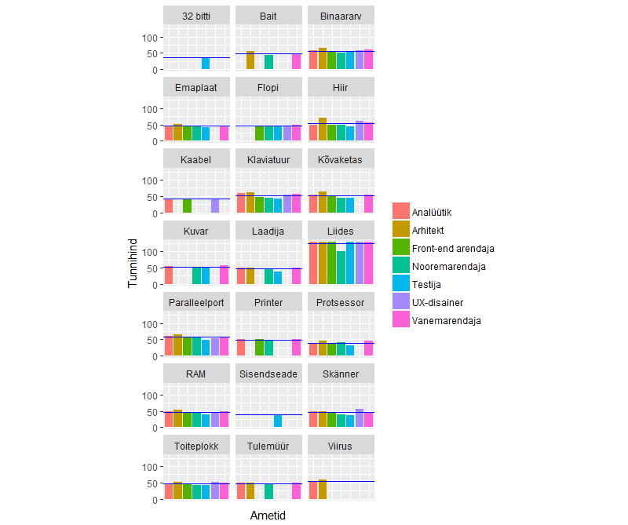

Joonis 2: hankes pakutud tunnihinnad eurodes ettevõtete lõikes

Esmalt paistab silma, et kõikide ametite tunnihinnad on enam-vähem võrdsed. Sinine joon tähistab hankes pakutud tunnihindade aritmeetilist keskmist. Mitmel juhul küsitakse just arhitekti töö eest keskmisest kõrgemat tunnihinda ning nooremarendaja ja testija töö eest keskmisest madalamat tunnihinda. Ettevõtete lõikes jäävad keskmised tunnihinnad sarnasele tasemele, välja arvatud ettevõte Liidese puhul. Seega antud hanke põhjal võiks Mati tutvust teha just ettevõtte Liidesega.

Mati tädi Kati omab väikefirmat, mis toodab ja müüb käsitöö seepe. Äril on hakanud niivõrd hästi minema, et Katil on soov avada e-pood. Kahjuks on vennapoeg Mati ülikooli lõpetamas ning suure koolikoormuse tõttu pole aega oma armast tädi aidata. Kati aga seevastu ei saa oodata, mistõttu on ta huvitatud IT-teenuse sisseostmisest. Kati veetis õhtupooliku erinevaid IT-firmasid guugeldades ning leidis, et valida on nii väga suurte kui ka väga väikeste ettevõtete vahel. Kati esimene mõte oli, et töö võiks sisse osta väikesest firmast, kuna tõenäoliselt on tegu alustava ettevõttega ning teenust müüakse odavamalt. Suured ettevõtted on juba endale nime teinud, mistõttu saavad nad endale lubada ka kõrgemaid hindu. Samas võib asi olla täpselt vastupidi - väikestel ettevõtetel on vaja ellu jääda ning seega peavad oma tööd müüma ka kõrge hinnaga. Kati segadus suurenes, kuna nende kahe näitaja vahel ei pruugi seost üldse olla. Katit hakkas huvitama, et kas vastab tõele, et ettevõtte suurus võib mõjutada keskmist tunnihinda, millega teenust müüakse?

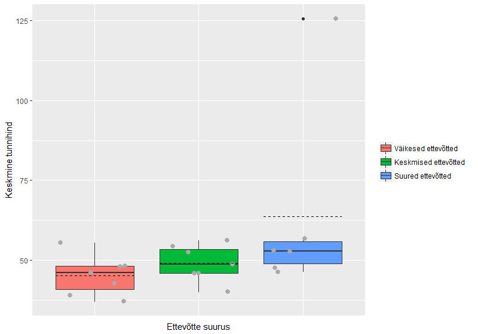

Joonis 3: keskmised tunnihinnad eri suurustes ettevõtetes

Ettevõtted on jagatud täiskohaga töötajate arvu järgi kolme kategooriasse. Väikestes ettevõtetes on kuni 20 töötajat, keskmistes kuni 100 ning suurtes üle 100 töötaja. Märkame, et ettevõtte suurus on tõesti seotud keskmise tunnihinnaga. Mida väiksem on ettevõte, seda madalama tunnihinnaga nad keskmiselt ametite teenuseid müüvad. Olemasolevate andmete põhjal oleks Katil kõige mõistlikum teenus sisse osta mõnest väikemast ettevõttest.

Mõeldud-tehtud! Kati saatis väljavalitud väikeettevõttele e-kirja, kuid ootab vastust juba mitu nädalat. Kati arvas, et tõenäoliselt pole ta ainus, kes tabas ära, et tõenäoliselt väiksematel firmadel on odavamad hinnad. Ta seletas e-kirjale vastuse mittesaamist sellega, et väikesed ettevõtted on tööga ülekoormatud. Kas väikesed ettevõtted müüvad rohkem teenust välja kui suuremad ettevõtted?

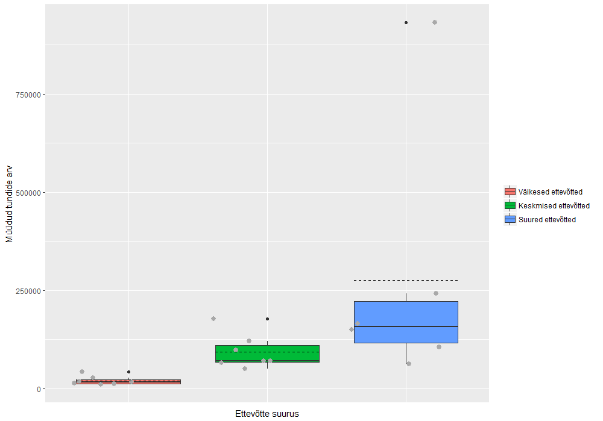

Joonis 4: müüdud tundide arv ettevõtte suuruse lõikes ettevõtetes

Aassta 2015 kohta esitatud majandusaasta aruannetest* uurisime välja, kuidas ettevõttetel sel aastal läks- mis oli nende käive ning kui suureks osutus kasum. Jagades käibe keskmise tunnihinnaga, saame hinnata, kui mitu tundi suutis iga ettevõte 2015 aasta jooksul välja müüa. Näeme, et tegelikkus on hoopis vastupidine Kati hüpoteesile - suuremad ettevõtted müüvad aastas rohkem töötunde, mis on igati ootuspärane. Ka Kati mõistab leitu loogilisust. Suuremates ettevõtetes on tööl rohkem spetsialiste, mistõttu on neil ressurssi ka rohkem töötunde maha müüa! Tuntud bränd ja hea maine hoiavad nõudlust firmade teenuste järele kõrgena, mis omakorda võimaldab neil küsida töötunni eest rohkem raha. Katil soovitame siiski oodata kirjale vastust väikesest IT-ettevõttest, kuna ta ettevõtte on alles algusjärgus.

Kati klassivend Karl on hiljuti saanud suure päranduse omanikuks ning otsib võimalusi, kuhu raha investeerida. Kati rääkis talle hiljuti toimunud klassikokkutulekul, et õepoeg Mati õpib infotehnoloogiat ning hakkab tulevikus palju raha teenima. Investor Karl on aga põhjalik mees, ta ei tee ühtegi otsust läbimõtlemata mõne kõlaka põhjal. Enne investeerimist soovib ta teada, millised on eri IT-ettevõtete strateegiad teenuse väljamüümisel ning kas mõni neist strateegiatest tagab suurema tulu. Selleks vaatame, kas ja kuidas on omavahel seotud keskmised tunnihinnad, müüdud tundide hulk aastas ning müügitulu.

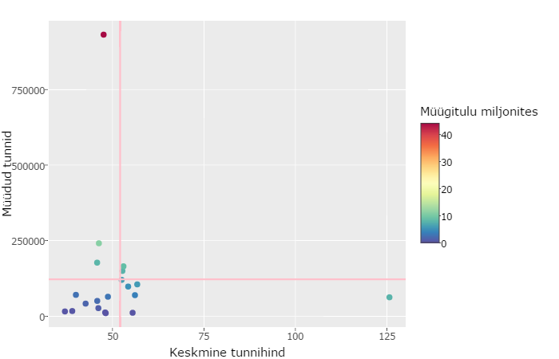

Joonis 5: müüdud tundide seos keskmise tunnihinnaga ja müügituluga.

Sarnaselt eelnevaga jagades käibe keskmise tunnihinnaga, saame hinnata, kui mitu tundi suutis iga ettevõte 2015 aasta jooksul välja müüa. Ühtlasi on teada keskmine tunnihind ning nende 2015. aastal teenitud müügitulu. Ettevõte edukust võivad tagada erinevad strateegiad. Kas suuremat tulu toob ettevõttele müüa palju tunde odava hinnaga või pigem küsida suuremat tunnihinda ja teha vähem tööd?

Joonisel 5 on esitatud x-teljel keskmine tunnihind ja y-teljel aasta jooksul välja müüdud tunnid. Seejuures peame silmas, et iga ettevõtte soov on müüa välja niipalju tunde kui võimalik. Roosade joontega on tähistatud üle kõikide ettevõtete keskmised tunnihinnad ja müüdud tundide arv.

Nagu näha, siis keskmisest rohkem tunde tööd teinud ettevõttete müügitulu on suurem kui nendel ettevõtetel, kes on keskmisest vähem töötunde müünud. Samas paneme tähele, et nende keskmine tunnihind on alla keskmise või siis keskmise lähedane. Silma paistab ettevõte Toiteplokk, kelle müügitulu on kordades suurem, kuid kes selle saamiseks küsib töö eest keskmisest väiksemat tunnihinda. Samas on muljetavaldav nende müüdud töötundide arv 2015. aastal. Nagu eelpool sai mainitud, siis Liidese tunnihinnad on kõige kõrgemad, mille juures saavad nad endale lubada ka keskmisest vähem töötunde. Samas ei saaks öelda, et võrreldes teiste ettevõtetega teeks nad töötunde vähem. Kuigi tulemused on põnevad, ei saa jooniselt välja lugeda ühte kindlat eduvalemit. Karl võiks kalkuleeritud otsuse tegemiseks tutvuda ettevõtete majandusaasta aruannetega.

Täpselt seda Karl teha ka otsustas. Tähistame iga ettevõtte numbriga (Tabel 1) ning uurime, kuidas neil 2015. aastal läks.

| Nr | Nimi | Nr | Nimi |
| --- | --- | --- | --- |
| 1 | 32 bitti | 11 | Emaplaat |
| 2 | Kõvaketas | 12 | Flopi |
| 3 | Klaviatuur | 13 | Liides |
| 4 | Binaararv | 14 | Hiir |
| 5 | Kaabel | 15 | Kuvar |
| 6 | Protsessor | 16 | Printer |
| 7 | Bait | 17 | Paralleelport |
| 8 | RAM | 18 | Sisendseade |
| 9 | Skänner | 19 | Viirus |
| 10 | Toiteplokk | 20 | Tulemüür |

Tabel 1: ettevõtete tähised

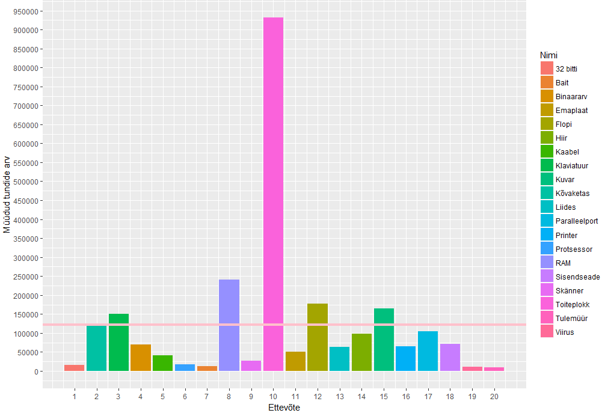

Joonis 6: müüdud tundide arv ettevõtete lõikes

Näeme, et üle keskmise tulemuse tegid viis ettevõtet: Klaviatuur, RAM, Toiteplokk, Flopi ja Kuvar. Seejuures on muljetavaldav ettevõtte Toiteplokk tulemus. Ettevõtted võivad väga edukalt müüa tunde välja, kuid see pole ainus ettevõtte edu pant. Tuleb olla ka tark väljaminekutega. Viskame pilgu peale ettevõtete kasumitele!

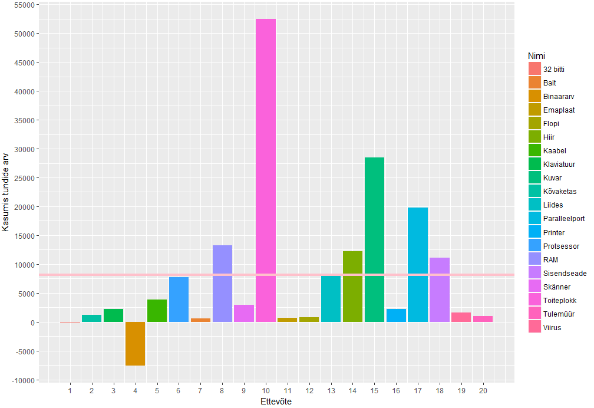

Joonis 7: kasum tundides ettevõtete lõikes

Mõni Kaval-Ants võib samuti aastaaruandeid uurida ja kasumite järgi kokku viia, mis ettevõtted on siin väljamõeldud nimede taha peidetud. Seetõttu jagasime kasumid läbi ettevõtte keskmise tunnihinnaga. Tulemuseks näeme, mitme tunniga on ettevõte aasta jooksul plussis või miinuses. Märkame kohe, et tõesti - kõik ettevõtted ei ole kasumis. Anname aru, et suured väljaminekud võivad olla investeeringud paremaks tulevikuks laenude näol. Seega vähene kasum või isegi kahjum võib olla strateegiline otsus.

*Allikas www.infopank.ee  
** Autorid märgivad ära, et nad ei tea, kas Karl soovib panna kõik kuldmunad ühte korvi või hajutada riske. Kuna on teada ainult ühe hanke pakkumise hinnad, oleks liialt ambitsioonikas anda täpseid ülevaateid ja hinnanguid IT-ettevõtete käekäigust.